# section3

> **Optimal Number of Clusters**
- ** K=5** might be suitable as prioritizing minimizing distortion and capturing more granular patterns.

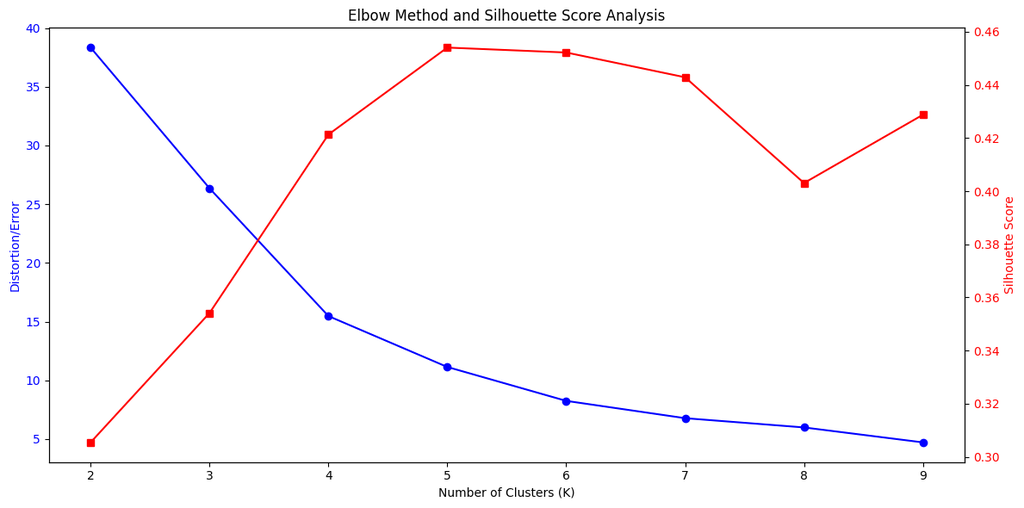

```python
pca = PCA(n_components=4)
X_pca=pca.fit_transform(profile_x_scaled_df)
plot_k_elbow(X_pca,10)
```

The first principal component (PC1) seems to represent overall sales performance or business success, as it is positively influenced by features such as weekly sales, markdowns, and store size, while negatively influenced by external economic factors like CPI and temperature.

Stores with larger sizes, higher weekly sales, and higher markdowns contribute more positively to this component. Higher CPI and temperature (presumably reflecting external conditions) are negatively correlated with this component, possibly indicating that economic or environmental factors might reduce sales performance.

```python
components = pca.components_
loadings = pd.DataFrame(components, columns=profile_x_scaled_df.columns, index=[f'PC{i+1}' for i in range(components.shape[0])])
print("Loadings of the first principal component (PC1):")
print(loadings.loc['PC1'])
```

```
Loadings of the first principal component (PC1):
Weekly_Sales_mean        0.301987
Weekly_Sales_min         0.286946
Weekly_Sales_max         0.308772
Weekly_Sales_std         0.295667
Temperature_mean        -0.086061
MarkDown_group145_sum    0.294837
MarkDown2_sum            0.301976
MarkDown3_sum            0.259133
CPI_mean                -0.259031
CPI_min                 -0.260179
CPI_max                 -0.258494
Size_first               0.311374
Total_Markdown           0.304084
Name: PC1, dtype: float64
```

For PC2, the loadings suggest that it is influenced heavily by economic indicators (CPI values) and store characteristics, with a notable contribution from the CPI_mean, CPI_min, and CPI_max features.

```python
print("Loadings of the second principal component (PC2):")
print(loadings.loc['PC2'])
```

```
Loadings of the second principal component (PC2):
Weekly_Sales_mean        0.172692
Weekly_Sales_min         0.186908
Weekly_Sales_max         0.163357
Weekly_Sales_std         0.132626
Temperature_mean         0.087948
MarkDown_group145_sum    0.115551
MarkDown2_sum            0.148464
MarkDown3_sum            0.098228
CPI_mean                 0.508971
CPI_min                  0.510629
CPI_max                  0.508250
Size_first               0.209877
Total_Markdown           0.126612
Name: PC2, dtype: float64
```

```python
print("Loadings of the third principal component (PC3):")
print(loadings.loc['PC3'])
```

```
Loadings of the third principal component (PC3):
Weekly_Sales_mean        0.118689
Weekly_Sales_min         0.180384
Weekly_Sales_max         0.046893
Weekly_Sales_std        -0.023674
Temperature_mean         0.948420
MarkDown_group145_sum    0.038870
MarkDown2_sum            0.011673
MarkDown3_sum           -0.146096
CPI_mean                -0.071007
CPI_min                 -0.069970
CPI_max                 -0.067970
Size_first              -0.111781
Total_Markdown          -0.032717
Name: PC3, dtype: float64
```

```python
print("Loadings of the fourth principal component (PC4):")
print(loadings.loc['PC4'])
```

```
Loadings of the fourth principal component (PC4):
Weekly_Sales_mean       -0.019124
Weekly_Sales_min         0.049500
Weekly_Sales_max        -0.144140
Weekly_Sales_std        -0.297616
Temperature_mean         0.017463
MarkDown_group145_sum    0.168595
MarkDown2_sum           -0.232228
MarkDown3_sum           -0.359747
CPI_mean                -0.031610
CPI_min                 -0.032333
CPI_max                 -0.031283
Size_first               0.810680
Total_Markdown          -0.124618
Name: PC4, dtype: float64
```

```python
pca_columns = [
    "Retail Success Factor - Larger Sizes and Higher Markdowns",
    "Economic Sensitivity - CPI",
    "Climate Influence – Temperature-Driven Sales Patterns",
    "Operational Scale – Larger Store Sizes with Reduced Markdown"
]

X_pca_df = pd.DataFrame(X_pca, columns=pca_columns)
X_pca_df.head()
```

|  | Retail Success Factor - Larger Sizes and Higher Markdowns | Economic Sensitivity - CPI | Climate Influence – Temperature-Driven Sales Patterns | Operational Scale – Larger Store Sizes with Reduced Markdown |
| --- | --- | --- | --- | --- |
| 0 | -0.083084 | 0.945349 | 0.180553 | 0.030112 |
| 1 | 0.636193 | 1.306152 | 0.195650 | -0.060658 |
| 2 | -1.275479 | 0.383321 | 0.126219 | -0.223829 |
| 3 | 1.463638 | -0.133800 | 0.241659 | 0.037691 |
| 4 | -1.272157 | 0.312914 | 0.077948 | -0.196145 |

```python
color_map = {
    0: 'blue',
    1: "red",
    2: "green",
    3: "purple",
    4: 'orange'
}
```

```python
def kmeans_clustering(X, y_storeName,n_cluster, custom_template, feature_names=None):
    # If X is a pandas DataFrame, keep it as is
    if isinstance(X, pd.DataFrame):
        feature_x = X.iloc[:, 0]  # The first feature (column)
        feature_y = X.iloc[:, 1]  # The second feature (column)
    else:
        # If X is a numpy ndarray, specify the column names manually or handle accordingly
        feature_x = X[:, 0]
        feature_y = X[:, 1]

    kmeans = KMeans(n_clusters=n_cluster, random_state=42)
    y_kmeans = kmeans.fit_predict(X)
    labels = kmeans.labels_

    # Compute silhouette score
    silhouette_avg = silhouette_score(X, y_kmeans)
    print(f'Silhouette Score: {silhouette_avg:.4f}')

    # Plot using Plotly with custom template
    fig = pg.Figure()

    # Scatter plot for the clusters
    fig.add_trace(pg.Scatter(
        x=feature_x, y=feature_y,
        mode='markers',
        marker=dict(
            color=[color_map[i] for i in y_kmeans],  # Assign colors based on cluster labels
            size=10
        ),
        text=[f"Cluster {i}" for i in y_kmeans],
        name='Clusters'
    ))


    # Mark the centroids
    centers = kmeans.cluster_centers_
    fig.add_trace(pg.Scatter(
        x=centers[:, 0], y=centers[:, 1],
        mode='markers',
        marker=dict(color='black', size=13, symbol='x'),
        name='Centroids'
    ))

    # Update layout with the custom template
    fig.update_layout(
        title=format_title(f'K-Means Clustering (Silhouette Score: {silhouette_avg:.4f})'),
        xaxis_title=f'{feature_names[0]}' if feature_names and len(feature_names) > 0 else 'Feature 1',  # Use provided column names or default
        yaxis_title=f'{feature_names[1]}' if feature_names and len(feature_names) > 1 else 'Feature 2',  # Use provided column names or default
        template=custom_template,
        legend=dict(title='Clusters'),
        showlegend=True
    )
    fig.show()
    return labels

# Example usage
# Assuming `profile_x_scaled_df` is your feature data (as a pandas DataFrame)
feature_names = list(X_pca_df.columns)  # Convert to list if necessary
labels = kmeans_clustering(X_pca_df,profile_y, 5, custom_template, feature_names=feature_names)
```

```
Silhouette Score: 0.4653
```

[interactive chart not shown]

```python
store_profile_df['cluster']=labels
store_profile_df.head(5)
```

|  | Store_ | Weekly_Sales_mean | Weekly_Sales_min | Weekly_Sales_max | Weekly_Sales_std | Temperature_mean | MarkDown_group145_sum | MarkDown2_sum | MarkDown3_sum | CPI_mean | CPI_min | CPI_max | Size_first | Total_Markdown | cluster |
| --- | --- | --- | --- | --- | --- | --- | --- | --- | --- | --- | --- | --- | --- | --- | --- |
| 0 | 1 | 1.542008e+06 | 1316899.31 | 2387950.20 | 169377.070424 | 67.5811 | 109955.31 | 52673.92 | 58818.12 | 213.563758 | 210.337426 | 219.535990 | 151315 | 221447.35 | 2 |
| 1 | 2 | 1.938857e+06 | 1650394.44 | 3436007.68 | 274681.325478 | 67.3423 | 135603.15 | 114448.38 | 82233.17 | 213.218275 | 209.998458 | 219.177306 | 202307 | 332284.70 | 2 |
| 2 | 3 | 3.956230e+05 | 339597.38 | 605990.41 | 50546.690975 | 70.7246 | 38705.20 | 16422.08 | 39386.37 | 216.909037 | 213.619614 | 223.009084 | 37392 | 94513.65 | 1 |
| 3 | 4 | 2.067728e+06 | 1762539.30 | 3676388.98 | 307174.734492 | 60.6608 | 145232.22 | 90382.91 | 92516.79 | 127.760328 | 126.064000 | 130.071032 | 205863 | 328131.92 | 3 |
| 4 | 5 | 3.130685e+05 | 260636.71 | 507900.07 | 41887.055884 | 68.5979 | 53572.10 | 19150.22 | 30808.45 | 214.124179 | 210.887277 | 220.117823 | 34875 | 103530.77 | 1 |

> **Cluster Portfolio**